# Assignment 3: Model comparison

Marton Kovacs

In this lab assignment you are going to work with (simulated) data related to perioperative pain and its psychological and hormonal predictors. In the assignment you will assess the added benefit of including some psychological and hormonal predictors to the already established demographic predictors of pain.

In this assignment you will set up a hierarchical regression model to predict postoperative pain after wisdom tooth surgery.

# Research problem

The amount of pain experienced around and after surgeries are highly variable between and within individuals. In order to improve surgical pain management regimens we need to understand what influences pain around surgical procedures and predict the amount of pain an individual will experience.

Your first study in this area is related to assessing the influence of trait and state psychological measures on pain, and to see whether taking into account these variables can improve our understanding of postoperative pain.

# Procedures and measures

Use the data file called ‘assignment_3_dataset’, from the ‘data/’ folder.

You have collected data from 160 adults who were scheduled to undergo surgical extraction of the third mandibular molar (wisdom tooth surgery). Patients filled out a form in the waiting room before their surgery. The form contained questions about their sex, age, and weight, and psychological questionnaires assessing anxiety, pain catastrophizing, and mindfulness (see descriptions below). You also got blood samples and saliva samples from participants in the waiting room 5 minutes before their operations to determine the serum (a component of the blood) and salivary cortisol levels of participants. Participants were contacted 5 hours after the surgery to see how much pain they were experiencing. The **level of pain** at that moment was recorded using a numerical rating scale using a **scale of 0 to 10**, where 0 means “no pain” and 10 means “worst pain I can imagine”.

**The State Trait Anxiety Inventory:** T measures trait anxiety on a scale of 20 to 80, higher scores mean higher anxiety. Anxiety has been found in many studies to positively correlate with the level of pain experienced. This is **variable STAI_trait** in the dataset.

**The Pain Catastrophizing Scale** measures the extent of pain catastrophizing, which is characterized by a tendency to magnify the threat value of a pain stimulus and to feel helpless in the presence of pain, as well as by a relative inability to prevent or inhibit pain-related thoughts in anticipation of, during, or following a painful event. The total score on this scale ranges from 0 to 52, higher scores mean higher catastrophizing. Pain catastrophizing is one of the well-established predictors of clinical pain. This is **variable pain_cat** in the dataset.

**The Mindful Attention Awareness Scale (MAAS)** measures dispositional mindfulness, which may be described as a tendency to turn attention to present-moment experiences in an open, non-judgmental way. The MAAS total score ranges from 1 to 6 (an average of the item scores), with higher scores representing higher dispositional mindfulness. Trait mindfulness has been theorized to serve as a protective factor against pain, as the individual would be more objective about their pain experience and tend to associate less discomfort, despair, and hopelessness to the pain-related sensations. This is **variable mindfulness** in the dataset.

**Cortisol** is a stress hormone associated with acute and chronic stress. Cortisol levels are thought to be positively associated with pain experience. Cortisol can be **measured from both blood and the saliva**, although, serum cortisol is often regarded in medical research as more reliably related to stress (serum is a component of the blood plasma). These are **variables cortisol_serum**, and **cortisol_saliva** in the dataset.

# Research question

Previous studies and meta-analyses showed that age and sex are often predictors of pain (age is negatively associated with pain, while sex is a predictor more dependent on the type of the procedure). You would like to determine the extent to which taking into account psychological and hormonal variables aside from the already used demographic variables would improve our understanding of postoperative pain.

To answer this research question you will **need to compare two models** (with a hierarchical regression). The **simpler model** should contain **age and sex as predictors of pain**, while the **more complex model** should contain the **predictors: age, sex, STAI, pain catastrophizing, mindfulness, and cortisol measures**. Notice that the predictors used in the simpler model are a subset of the predictors used in more complex model. **You will have to do model comparison to assess whether substantial new information was gained about pain in the more complex model compared to the simpler model.**

# What to report

As usual, before you can interpret your model, you will need to run data and model diagnostics. First, check the variables included in the more complex model (age, sex, STAI, pain catastrophizing, mindfulness, and cortisol measures as predictors, and pain as an outcome) for **coding errors**, and the model itself for **influential outliers** (for example using Cook’s distance). Furthermore, check the final model to see if the **assumptions of linear regression hold true**, that is, **normality** (of the residuals), **linearity** (of the relationship), **homogeneity of variance** (also called homoscedasticity) and that there is no excess **multicollinearity** (“uncorrelated predictors” in Navarro’s words). If you find anything amiss during these checks, make the appropriate decision or correction and report your findings and actions in your report.

**Note:** If you do any changes, such as exclude cases, or exclude predictors from the model, you will have to re-run the above checks for your final data and model.

Report the results of the simpler model and the more complex model. For both models you should report the model test statistics (adj.R2, F, df, and p value). Also, report the statistics describing the coefficients of the predictors in a table format (unstandardized regression coefficients and 95% confidence intervals, standardized regression coefficients (B and Beta values), and p values).

Write up the regression equation of the more complex model in the form of 𝑌 = 𝑏0 + 𝑏1 ∗ X1 + 𝑏2 ∗ X2 +…+ bn * Xn, in which you use the actual regression coefficients of your models. (b0 stands for the intercept and b1, b2 … bn stand for the model coefficients for each of the predictors, and X1, X2, … Xn denote the predictors).

Compare the two models in terms of how much variance they explain of pain’s variability in the sample. Report Akaike information criterion (AIC) for both models and the F test statistic and p value of the likelihood ratio test comparing the two models.

# What to discuss

In your discussion of the findings, briefly interpret the results of the above analyses, and indicate whether you think that anything was gained by including the psychological and hormone measures in the model.

# Solution

## Read the data

Read the dataset used in this assignment. Pay attention to the extension of the datafile.

## Data and model diagnostics

### Data diagnostics

#### Descriptives of the variables

Run an exploratory data analysis (EDA) to investigate the dataset.

#### Correct coding errors

If you find values in the dataset during the EDA, that are not correct based on the provided descriptions of the variables of the dataset please correct them here.

**The following have been found** + sex included “woman” –> recoded to “female” + mindfulness had values above 6, which should have been the maximum. + pain had a value above the maximum of 10, this case was dropped

### Model diagnostics

#### Build the more complex model

**more complex model** should contain the **predictors: age, sex, STAI, pain catastrophizing, mindfulness, and cortisol measures**

In order to test the more complex model for outliers and to test the assumptions first build the model.

#### Checking for influential outliers

Check for outlier values in the model.

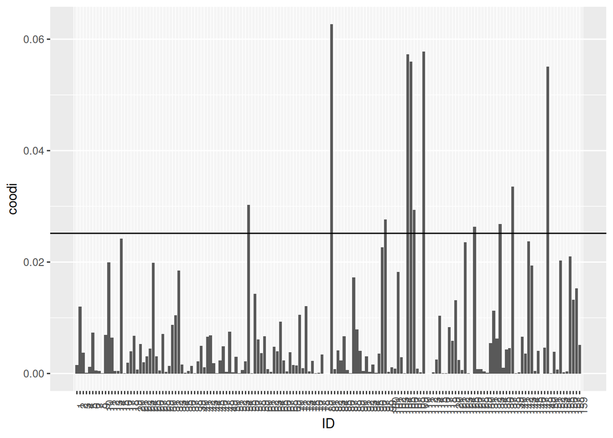

```r
coodi <- cooks.distance(mc)
coodi %>%
  as.data.frame() %>%
  rownames_to_column(var="ID") %>%
  mutate(ID = as.numeric(ID)) %>%
  ggplot(aes(x=ID,y=coodi))+geom_bar(stat="identity")+geom_hline(yintercept=4/nrow(crd))+theme(axis.text.x = element_text(angle=90))+scale_x_continuous(breaks=seq(1,159,1))
```

```r
#no element is D > 1, but a more rigorous 4/n correction shows some more influential observations
#creating a model with excluded cases
excl <- coodi %>%
  as.data.frame() %>%
  rownames_to_column(var="ID") %>%
  filter(coodi > 4/nrow(crd)) %>%
  select(ID)
excl <- as.numeric(unname(unlist(excl)))
crdwo <- crd[-excl,]
#re-creating model for later analysis
mcwo <- lm(pain ~ age + sex + STAI_trait + pain_cat + mindfulness + cortisol_saliva, data = crdwo)
```

#### Checking assumptions

Check the normality assumption.

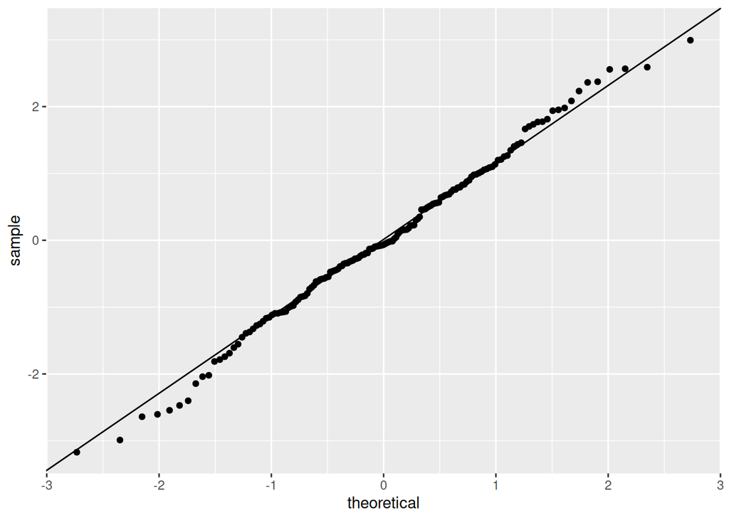

```r
residuals(mc) %>%
  as.data.frame() %>%
  ggplot(aes(sample=residuals(mc)))+stat_qq_line()+stat_qq() #QQ-plot doesn't indicate violation of normal distribution for residuals
```

Check the linearity assumption.

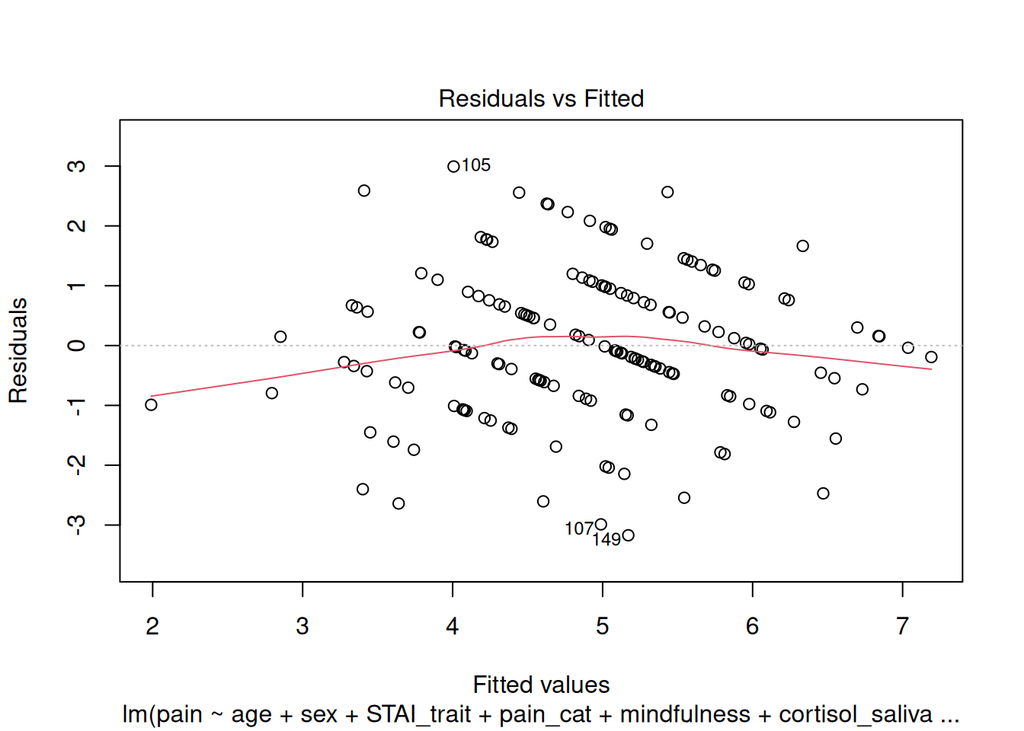

```r
plot(mc, which = 1)
```

```r
#residual vs fitted plot doesn't show the violation of the assumption of linearity.
```

Check the homoscedasticty assumption (homogeneity of variance).

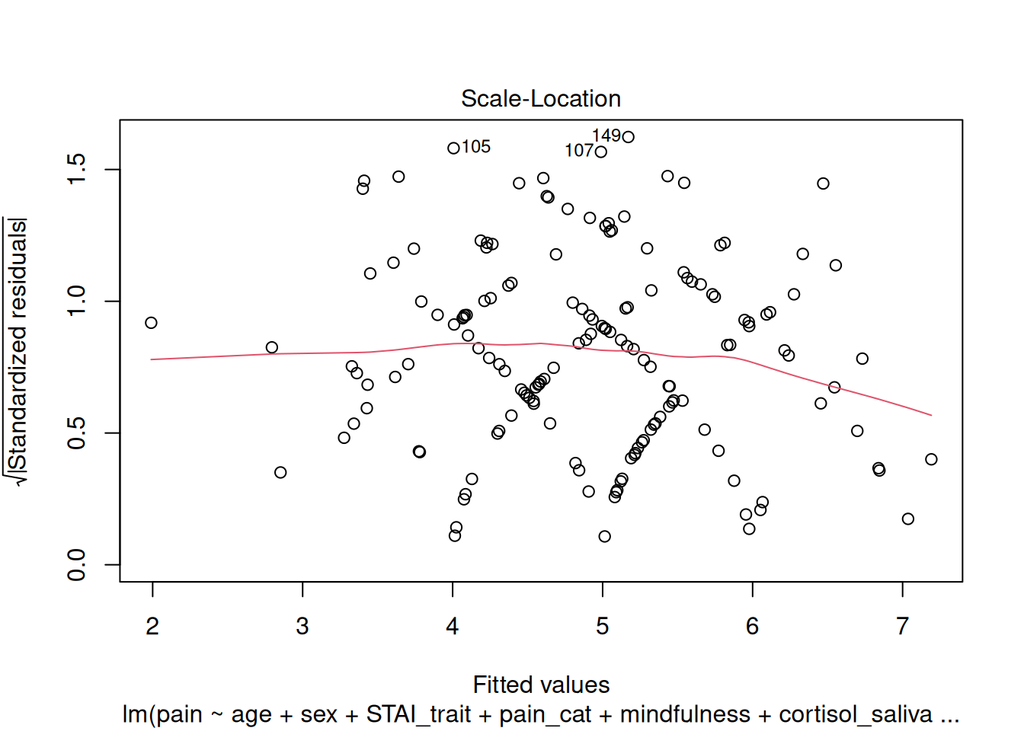

```r
plot(mc, which = 3)
```

```r
bptest(mc)
```

```
##
##  studentized Breusch-Pagan test
##
## data:  mc
## BP = 6.849, df = 7, p-value = 0.4448
```

```r
#trendline and Breusch-Pagan test suggest homoscedasticity
```

Check the multicollinearity assumption.

(VIF above 5), or a VIF threshold of 3 is recommended in this paper: http://onlinelibrary.wiley.com/doi/10.1111/j.2041-210X.2009.00001.x/full

Some info about VIF: https://statisticalhorizons.com/multicollinearity http://blog.minitab.com/blog/understanding-statistics/handling-multicollinearity-in-regression-analysis

```r
vif(mc)
```

```
##             age             sex      STAI_trait        pain_cat     mindfulness
##        1.534833        1.140291        2.102170        1.971166        1.504054
## cortisol_saliva  cortisol_serum
##        6.598379        6.063905
```

```r
cor(crd[,c(2, 4:12)], method="spearman") %>% #using spearman, because of violation of normal distribution at multiple vars, see at row 108
  as.data.frame() %>%
  rownames_to_column(var = "ID") %>%
  pivot_longer(!ID, names_to="measure",values_to="value") %>%
  filter(value >=0.8) %>%
  group_by(measure)
```

[output not shown]

```
## # A tibble: 12 × 3
## # Groups:   measure [10]
##    ID               measure          value
##    <chr>            <chr>            <dbl>
##  1 pain             pain             1
##  2 age              age              1
##  3 STAI_trait       STAI_trait       1
##  4 pain_cat         pain_cat         1
##  5 cortisol_serum   cortisol_serum   1
##  6 cortisol_serum   cortisol_saliva  0.904
##  7 cortisol_saliva  cortisol_serum   0.904
##  8 cortisol_saliva  cortisol_saliva  1
##  9 mindfulness      mindfulness      1
## 10 weight           weight           1
## 11 IQ               IQ               1
## 12 household_income household_income 1
```

```r
#The two cortisol measures are highly correlated
```